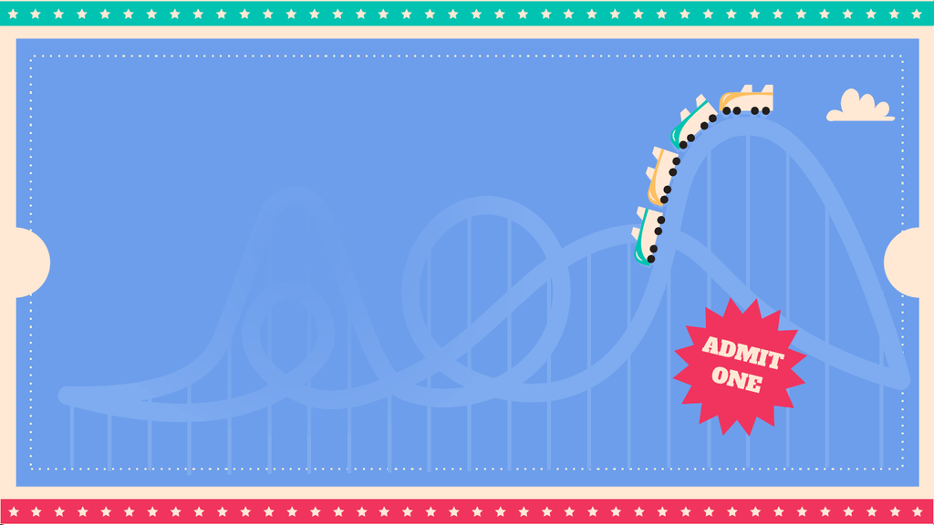

Sharlene World Simulation

Model

Documentation

Model Description

Simulation Objective:

•To simulate a theme park environment, including different types of rides and how they might

impact visitor experiences and the profits of the park.

Type of model used in the simulation:

•The model uses agent-based modelling, which means that individual agents are created to

represent the visitors to the park. These agents are programmed with different behaviors and

preferences, which influence how they interact with the park and its rides.

Output analysis:

•Data collected from the simulation is used to perform output analysis, which involves analyzing

the statistics and results generated by the simulation using various statistical analysis methods.

This analysis could include measures of agent satisfaction level and ride popularity.

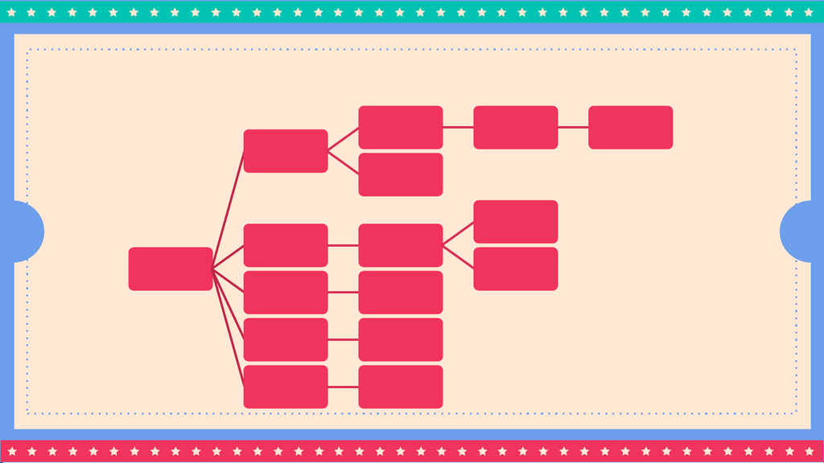

Overview of Code

Main function

Map Class

Array of MapNode

objects Map Node Object Update Agents in

MapNode

Shortest Path

Algorithm

Array of Agent

Objects Agent Object

Update Agent

States

Update next

MapNode Object

to travel to

Calculate Statistics Averages

User Interface Graph Display

Export to CSV Data for output

Analysis

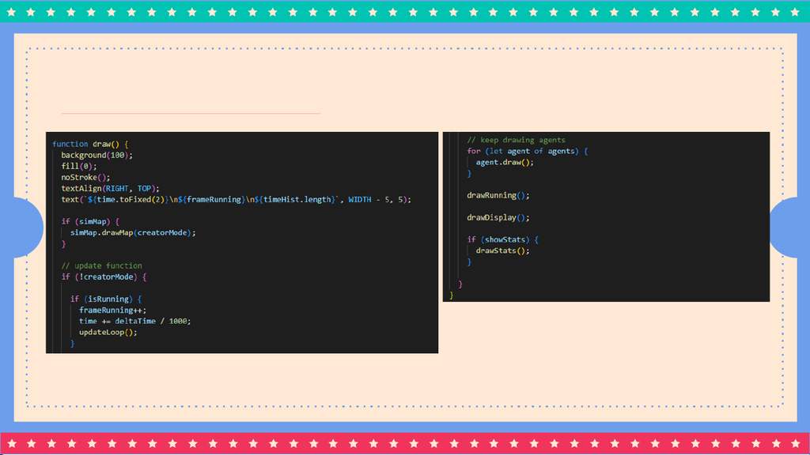

Final Coding

Main Loop for rides and agents

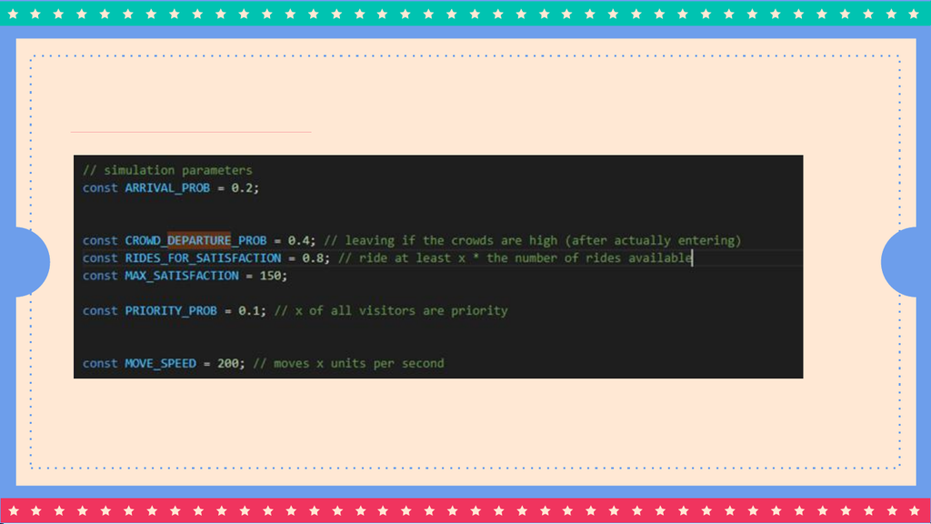

Final Coding

Simulation parameters

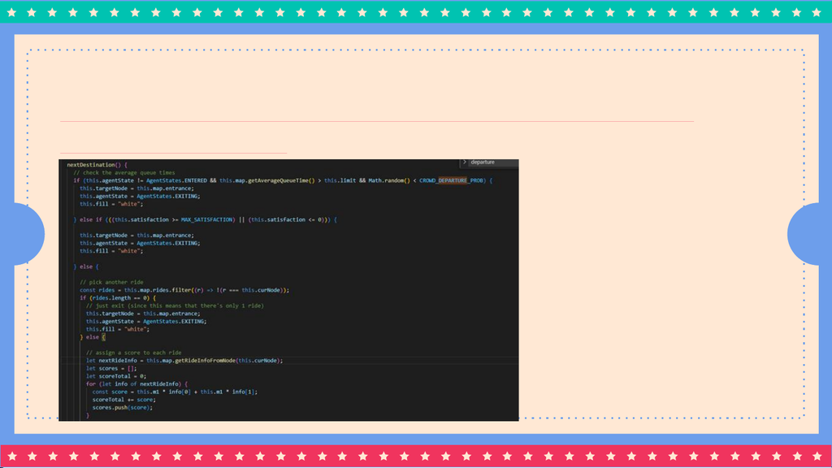

Final Coding

Agent next destination code, using queue and distance weights to

choose next destination

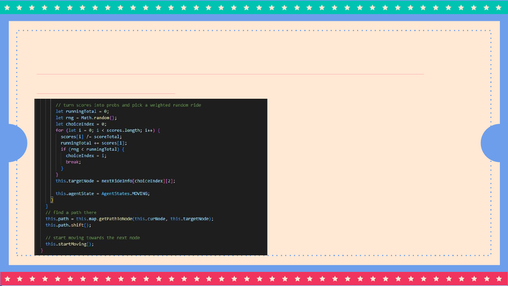

Final Coding

Agent next destination code, using queue and distance weights to

choose next destination

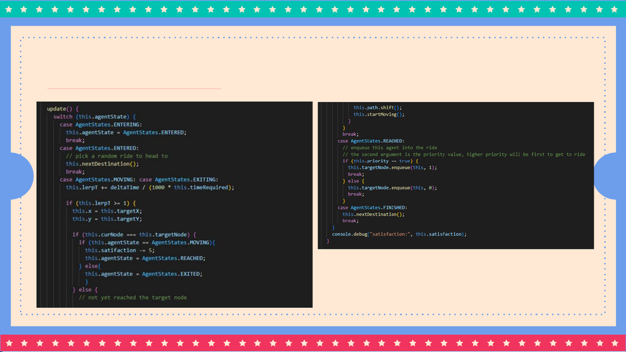

Final Coding

Agent state update loop

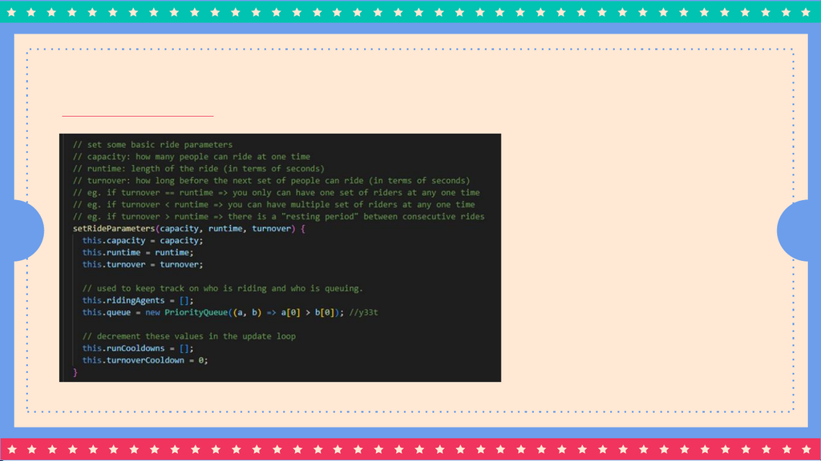

Final Coding

Ride parameters

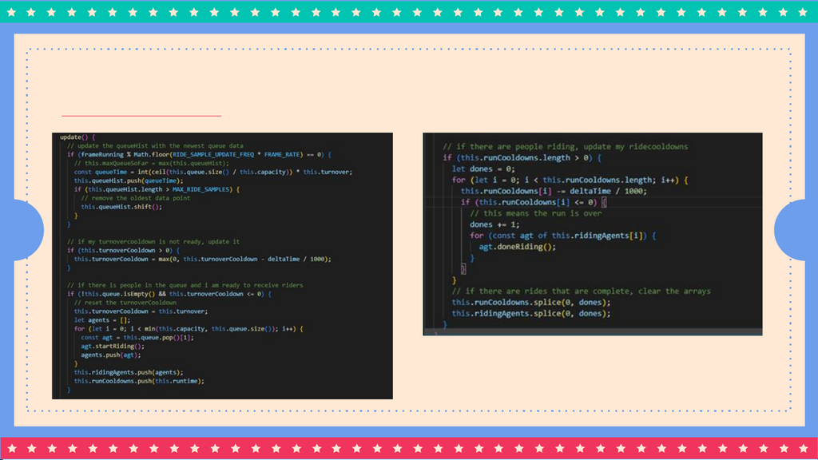

Final Coding

Ride update loop

Requirements

The simulation is divided into three main components:

1. Agents:

-Agents with the express pass are colored blue, while agents with the standard pass are labelled

green. When the agents are exiting the ride, they are colored white.

Agent Attributes:

•Satisfaction score: A numerical score that aims to simulate the “satisfaction level” of the agents

when they are in the theme park. A higher score means a higher satisfaction, and the satisfaction

level of the agents starts from 100. When the agents are queuing or moving to their next

destination, their satisfaction score will decrease. When they finish their rides, their satisfaction

score will increase.

•Priority: There are 2 types of passes in this theme park: standard pass vs express pass. If the

agent purchased the express pass, the agent would have priority over the standard pass. However,

the cost of the express pass is more than the cost of the standard pass.

•Current location: The location of the ride the agent is currently at.

Requirements

•Next location: The location of the ride/exit the agent is going to next.

•Agent State: The current state of the agents. (Refer to state diagram)

•Profits: The profits earned from each agent after each ride, calculated using (ticket cost –operation

cost). The data for this was found in the background data.

Agent Behavior:

•The agents will move from the entrance to their desired ride by calculating the shortest path to the

ride and walking over. This calculation will take into consideration the agent’s tolerance for queues

and walking distance to decide whether the agent wants to queue/ride in that specific ride.

Requirements

2. Rides:

capacity of the ride before starting the ride again.

Ride Attributes:

•Ride locations: The x and y coordinates of the ride in the park

•Type of Ride: The type of ride A, B or C. Each type of ride has different parameters.

Ride Parameters:

•Ride Capacity: The maximum capacity of the ride

•Ride Turnover: The time taken for the ride to get ready

•Ride Duration: The time taken for the ride to end

Requirements

3. Theme Park

•Collection of all the ride locations

•Collection of all the agents

•Collection of all the paths to the rides

Notes:

•Due to single inheritance limit in JavaScript, we created a Map class that takes in the rides as nodes.

•The rides themselves are a separate class known as Map Node, which helps to set the ride parameters

and the entrance etc.

•The visitors are objects that will interact with the rides under the Agent class.

•To allow the agent to interact with the rides, we have a main function that contains the map (which

contains the map nodes) and the agents.

First Draft Plan

Goal: Create a small version of simulation based on Proposal

Duration: Week 6 –8

Designers: Xin Yi, Jie Lin, Danny, Robin

Developers: Danny, Robin

First Draft Description

•The group aimed to create a scaled-down version of the theme park simulation.

•The simulation was designed so that agents chose their next rides randomly,

rather than based on specific preferences or behaviors.

•We limited the number of agents to just one in order to test whether the logic of

the simulation worked properly.

•The simulation was also limited to just two types of rides, rather than including

the full range of rides that might be present in a real theme park.

•Rides were programmed to accept agents as long as their capacity was not full,

rather than waiting to fill up a full batch of riders before starting the ride.

First Draft Description

•The simulation included a basic interface that displayed graphs showing

averages of various metrics, such as ride popularity and visitor satisfaction.

•The interface also allowed for live statistics to be displayed for each individual

ride, such as the current number of riders and the average wait time, which

could be viewed by hovering the mouse over the specific ride.

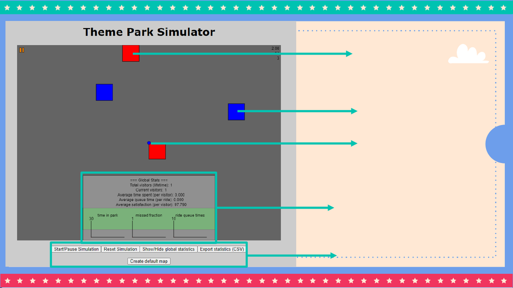

Represent Ride A

Represent Ride B

Agent (Visitor)

Graph & Statistic

Different navigation

function button

First Draft Problems

•After testing with 1 agent, we tried adding more agents and removing

the rectangles as it was blocking some agents for now.

•We found issues getting the shortest path algorithm to work correctly.

•Agents were going beyond the shortest paths.

•After fixing the issue with the shortest paths, we realized there was

an issue where some agents stopped moving prematurely.

•This was because of flaws in the update loop in the code, leading to

the linear interpolation of the agents to be wrong.

First Draft Problems

•In this first simulation, we did not calculate the profits, and there were

some errors in the linear interpolation of the shortest path as some of

the agents stopped moving prematurely. However, out of the agents

that moved properly, we could test that the simulation logic was valid.

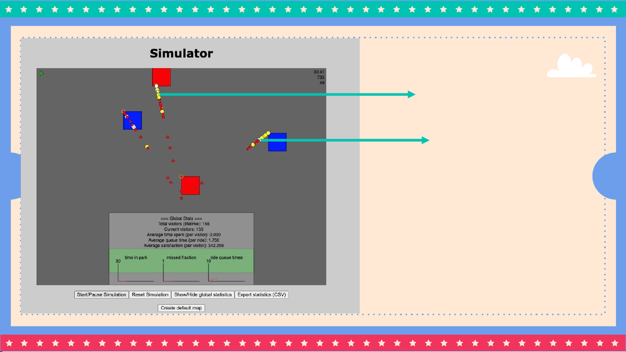

Despite us using

shortest paths, the

agents stopping

prematurely

Adding more agents

[figure not shown]

Final Simulation Plan

Goal: Create the final simulation

Duration: Week 9 - 12

Designers: Xin Yi, Jie Lin, Danny, Robin

Developers: Danny, Robin

Final Simulation Description

•The group focused on refining the final version of the theme park

simulation, addressing issues such as agents stopping prematurely or

walking out of the path.

•Rides were modified so that they operated by batch rather than a

continuous process, which made for a more realistic simulation as

compared to the first draft.

•Paths were drawn in the simulation to make it easier for users to

visualize the movement of agents throughout the park.

[figure not shown]

Final Simulation Limitation

Due to time constraints, the group was unable to

implement a creator mode for the simulation, which

would have allowed users to customize various aspects of

the park and its rides.

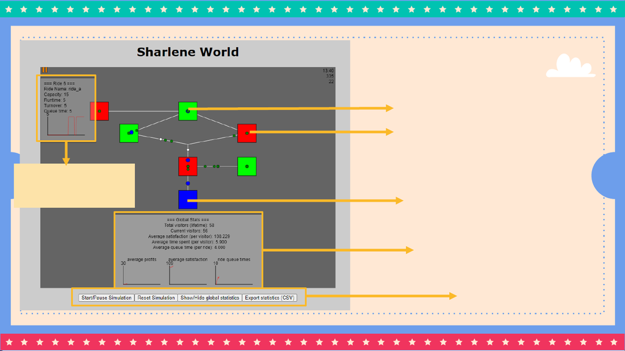

Scenario 1: Offer 2 different

type of rides (A&B)

Statistics for

individual ride when

hover over the ride Entrance of the theme park

Graphs & Statistics

Buttons to

Control Simulation

Ride A (Performance)

Ride B (Slow Train)

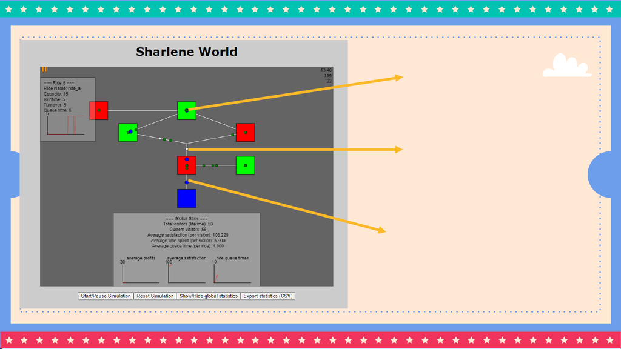

Green Agent: Standard

Pass (lower priority level

compared to express pass)

Blue Agent: Express Pass

(higher priority level compared to

standard pass)

White Agent: Exiting the ride

(when agent exit the ride, it will

turn white)

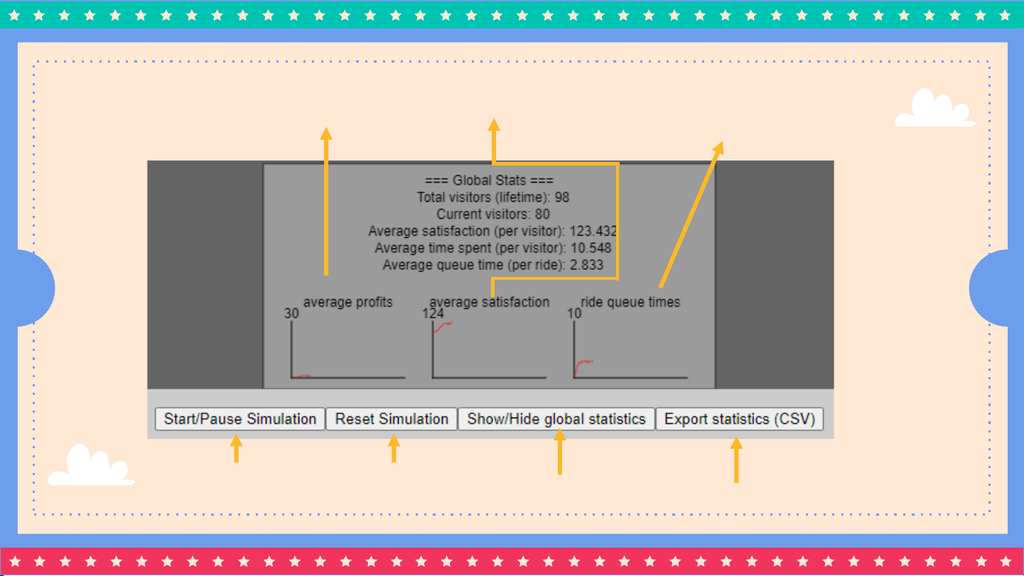

Average

profit per

visitor

Average

satisfaction per

visitor

Average ride queue time per

ride (averaging all the type of ride)

Export Statistic

into CSV format

Show/Hide the

graph & statistic

Reset

simulation

Start/Pause

simulation

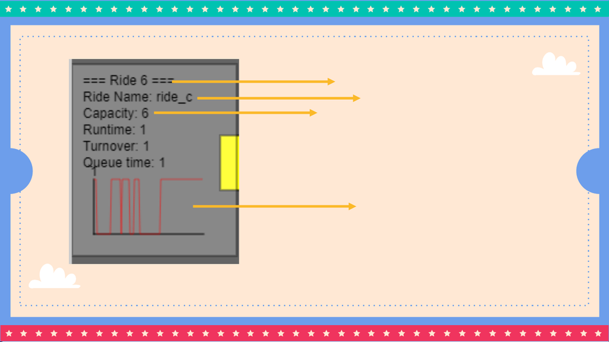

Ride number

Ride type

Queue Time

(can hover every individual ride in the

simulation to see the queue time )

Maximum number of agents can be on the

ride at a time

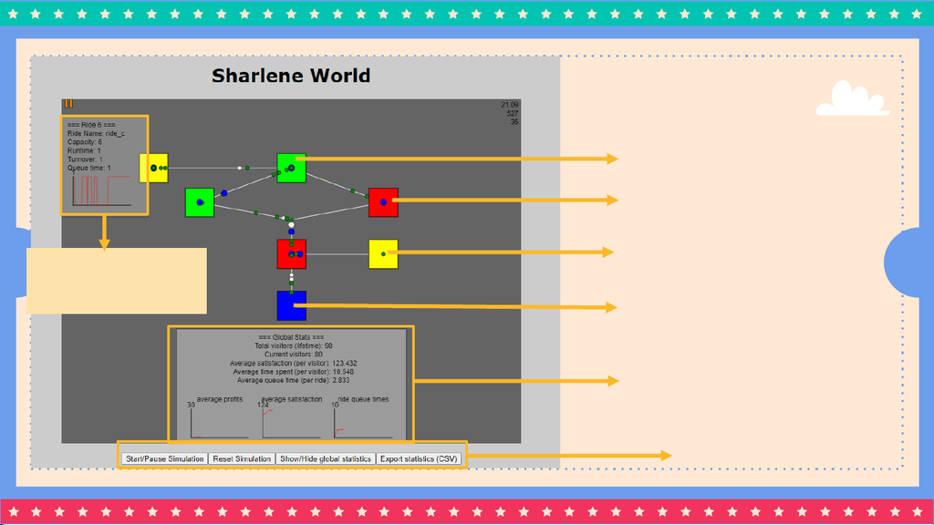

Entrance of the

theme park

Ride A (Performance)

Ride B (Slow Train)

Ride C (Spinning type)

Graphs & Statistics

Buttons to Control

Simulation

Statistics for

individual ride when

hover over the ride

Scenario 2: Offer 3 different

type of rides (A,B,C)

[figure not shown]

Code Sources

•https://www.w3schools.com/js/js_class_inheritance.asp

•https://p5js.org/reference/

•https://github.com/mickey1356/sim_project

•https://stackoverflow.com/questions/42919469/efficient-way-to-

implement-priority-queue-in-javascript

•https://en.wikipedia.org/wiki/Floyd%E2%80%93Warshall_algorit

hm

• Dijkstra’s Algorithm – Taken from SUTD Algorithms Notes